# error_analysis

Sara Orofino

12/2/2019

## Setup

```r
knitr::opts_chunk$set(echo = TRUE)

#Packages
library(tidyverse)
library(here)
library(RColorBrewer)

#Data
err_rep5u <- read_csv(file=file.path(here(),"/Results/error/error_updating_rep5.csv"))
err_rep5u_2 <- read_csv(file=file.path(here(),"/Results/error/error_updating_rep5_.1-.25.csv"))
err_rep10u <- read_csv(file=file.path(here(),"/Results/error/error_updating_rep10.csv"))
err_rep10u_2 <- read_csv(file=file.path(here(),"/Results/error/error_updating_rep10_.1-.25.csv"))

#Comparision of perfect management data
perfect <- read_csv(file=file.path(here(),"/tests/perfect_management/csv_results/perfect.csv"))
perfect_rep5 <- read_csv(file=file.path(here(),"/tests/perfect_management/csv_results/perfect_rep5.csv"))
perfect_fishe <- read_csv(file=file.path(here(),"/Results/error/perfect_updating_rep5.csv"))
```

## Decision Calculation

- Filter negative climate change
- Filter for assessment years ONLY
- Group simulations by error percentage
- Count the number of times the model chose a ratio that led the manager to make the wrong decision

**Rep5 - Updating**  
Do some basic data wrangling for 5 year intervals where Fmsy updating with climate change:  
- Look at all negative climate change scenarios  
- Look at ONLY assessments where a decision was actually made (filter out times when the fishery was closed)  
- Group by error percentage

Now I want to see how many “fails” were included in each error category

**Rep10 - Updating**  
Data wrangling for 10 year intervals where Fmsy is updating with climate change:

Now I want to see how many “fails” were included in each error category

## Table

**Rep5**  
Proportion of yes/no/fail for 5 year updating Fmsy at the three different errors:

| Error | Number of Assessments | Fail | Proportion of Failures | Number of Decisions Made | Number of Yes | Proportion of Yes | Number of No | Proportion of No |
| --- | --- | --- | --- | --- | --- | --- | --- | --- |
| 0.1 | 4536 | 646 | 0.142 | 3890 | 3265 | 0.839 | 625 | 0.161 |
| 0.3 | 4536 | 1793 | 0.395 | 2743 | 1864 | 0.680 | 879 | 0.320 |
| 0.5 | 4536 | 2752 | 0.607 | 1784 | 1055 | 0.591 | 729 | 0.409 |

Proportion of yes/no/fail for 5 year updating Fmsy at the three errors between 0.1 and 0.3:

| Error | Number of Assessments | Fail | Proportion of Failures | Number of Decisions Made | Number of Yes | Proportion of Yes | Number of No | Proportion of No |
| --- | --- | --- | --- | --- | --- | --- | --- | --- |
| 0.15 | 4536 | 751 | 0.166 | 3785 | 2960 | 0.782 | 825 | 0.218 |
| 0.20 | 4536 | 1172 | 0.258 | 3364 | 2492 | 0.741 | 872 | 0.259 |
| 0.25 | 4536 | 1536 | 0.339 | 3000 | 2109 | 0.703 | 891 | 0.297 |

**Rep10**

Proportion of yes/no/fail for 10 year updating Fmsy at the three different errors:

| Error | Number of Assessments | Fail | Proportion of Failures | Number of Decisions Made | Number of Yes | Proportion of Yes | Number of No | Proportion of No |
| --- | --- | --- | --- | --- | --- | --- | --- | --- |
| 0.1 | 2376 | 451 | 0.190 | 1925 | 1685 | 0.875 | 240 | 0.125 |
| 0.3 | 2376 | 834 | 0.351 | 1542 | 1044 | 0.677 | 498 | 0.323 |
| 0.5 | 2376 | 1126 | 0.474 | 1250 | 719 | 0.575 | 531 | 0.425 |

Proportion of yes/no/fail for 10 year updating Fmsy at the three different errors between 0.1 and 0.3:

| Error | Number of Assessments | Fail | Proportion of Failures | Number of Decisions Made | Number of Yes | Proportion of Yes | Number of No | Proportion of No |
| --- | --- | --- | --- | --- | --- | --- | --- | --- |
| 0.15 | 2376 | 532 | 0.224 | 1844 | 1518 | 0.823 | 326 | 0.177 |
| 0.20 | 2376 | 684 | 0.288 | 1692 | 1317 | 0.778 | 375 | 0.222 |
| 0.25 | 2376 | 711 | 0.299 | 1665 | 1199 | 0.720 | 466 | 0.280 |

## Visualizations

Experiment with a few ways of visualizing this data

**Rep5**

First try proportion of failures on the y-axis with error categories on the x-axis for updating Fmsy

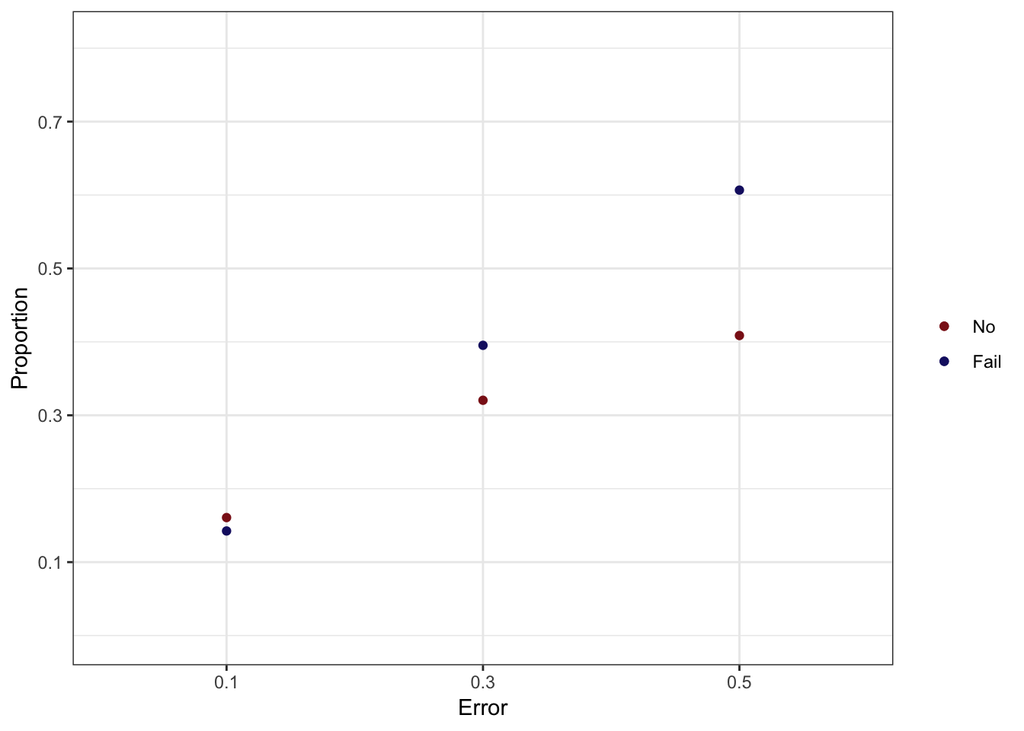

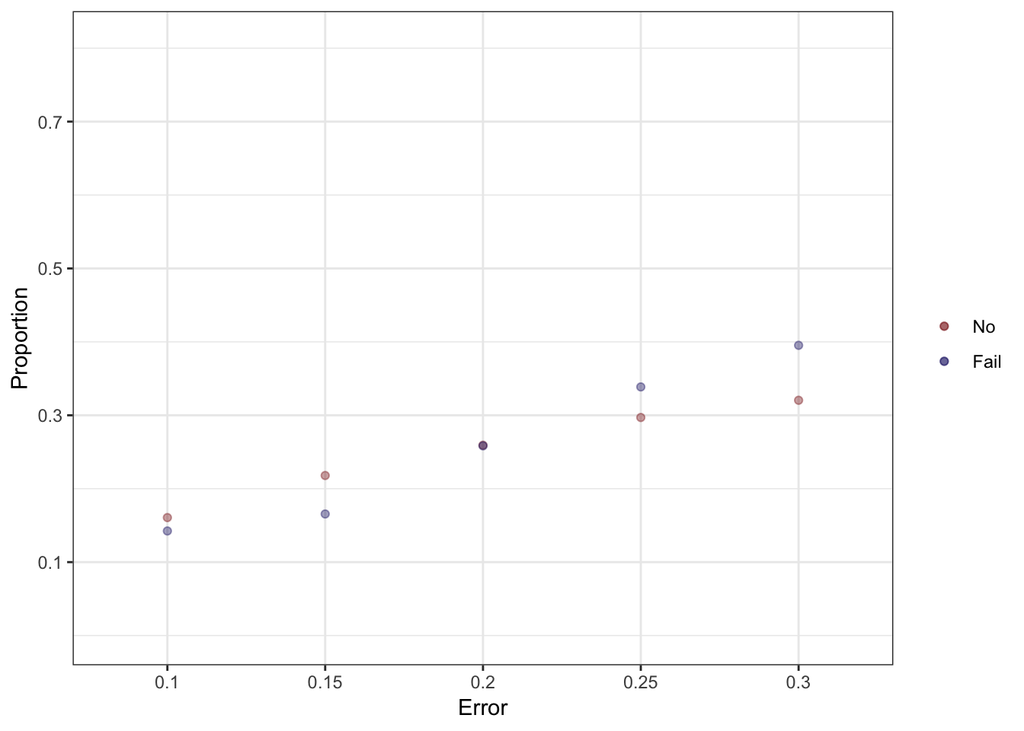

**Rep10**

First try proportion of failures on the y-axis with error categories on the x-axis for updating Fmsy

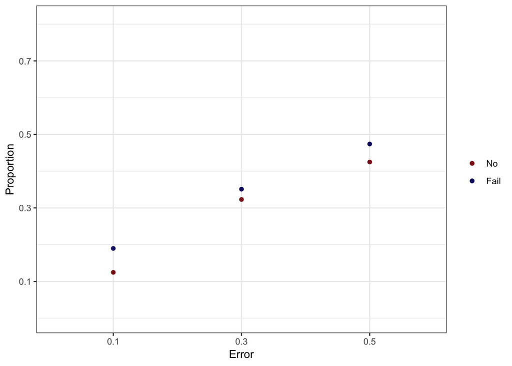

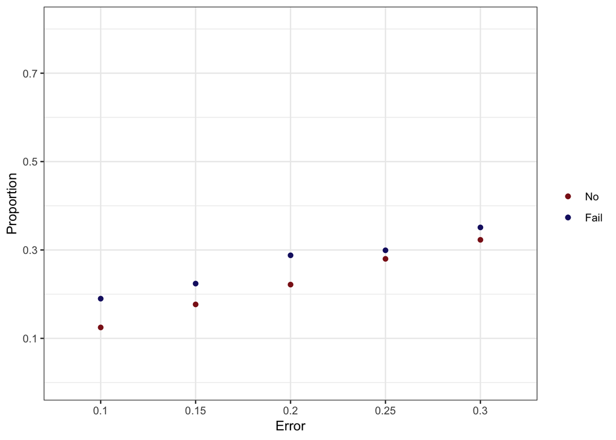

## Probability of Collapse

What’s the probability the fishery collapses under different amounts of error?

Find how many of the 1224 experiments collapsed. What was the most common year of collapse? The earliest year of collapse? The latest year of collapse? what’s the probability of the fishery collapsing at 5 or 10 year intervals if the error range is 0.1-0.5 vs 0.15-0.25?

**Rep5**  
In the first experiment (error 0.1, 0.3, 0.5) 538 fisheries collapsed  
- Most common year of collapse = 4  
- Minimum = Year 4  
- Maximum = Year 99

Probability of collapse = 43.95%

Looking at the error between 0.1 and 0.3 only 331 fisheries collapsed  
- Most common year of collapse = 4  
- Minimum = Year 4  
- Maximum = Year 99

Probability of collapse = 27.04%

**Rep10**  
In the first experiment (error 0.1, 0.3, 0.5) 503 fisheries collapsed  
- Most common year of collapse = 9  
- Minimum = Year 9  
- Maximum = Year 99

Probability of collapse = 41.09%

Looking at the error between 0.1 and 0.3 only 376 fisheries collapsed  
- Most common year of collapse = 9  
- Minimum = Year 9  
- Maximum = Year 99

Probability of collapse = 30.72%

For both 5 and 10 year intervals the most common year of fishery collapse was the year before the next assessment

Now we want a little more detail about the collapsed fisheries. First, how many fisheries collapsed at a 0.5 error vs 0.3 error vs. 0.1 error?

```r
total_experiments <- 1224

###### Rep 5
##Now look at the probability of failure at each of the three error points (0.1,0.3,0.5) and compare:
#0.1 Error
rep5_1 <- err_rep5u %>%
  filter(error == 0.1) %>%
  filter(decision_made == "no") %>%
  group_by(id) %>%
  tally()
collapse0.1_rep5 <- nrow(rep5_1)
rep5_0.1prob <- collapse0.1_rep5 / total_experiments
#0.3 Error
rep5_3 <- err_rep5u %>%
  filter(error == 0.3) %>%
  filter(decision_made == "no") %>%
  group_by(id) %>%
  tally()
collapse0.3_rep5 <- nrow(rep5_3)
rep5_0.3prob <- collapse0.3_rep5 / total_experiments
#0.5 Error
rep5_5 <- err_rep5u %>%
  filter(error == 0.5) %>%
  filter(decision_made == "no") %>%
  group_by(id) %>%
  tally()
collapse0.5_rep5 <- nrow(rep5_5)
rep5_0.5prob <- collapse0.5_rep5 / total_experiments

###### Rep 10
##Now look at the probability of failure at each of the three error points (0.1,0.3,0.5) and compare:
#0.1 Error
rep10_1 <- err_rep10u %>%
  filter(error == 0.1) %>%
  filter(decision_made == "no") %>%
  group_by(id) %>%
  tally()
collapse0.1_rep10 <- nrow(rep10_1)
rep10_0.1prob <- collapse0.1_rep10 / total_experiments
#0.3 Error
rep10_3 <- err_rep10u %>%
  filter(error == 0.3) %>%
  filter(decision_made == "no") %>%
  group_by(id) %>%
  tally()
collapse0.3_rep10 <- nrow(rep10_3)
rep10_0.3prob <- collapse0.3_rep10 / total_experiments
#0.5 Error
rep10_5 <- err_rep10u %>%
  filter(error == 0.5) %>%
  filter(decision_made == "no") %>%
  group_by(id) %>%
  tally()
collapse0.5_rep10 <- nrow(rep10_5)
rep10_0.5prob <- collapse0.5_rep10 / total_experiments
```

**Rep5**  
Probability of collapse at different errors:  
- 0.1: 4.82%  
- 0.3: 15.11%  
- 0.5: 24.02%

**Rep10**  
Probability of collapse at different errors:  
- 0.1: 6.54%  
- 0.3: 14.62%  
- 0.5: 19.93%

Are those differences significant?  
Use a chi square test to test for significant association in proportions  
Is there a significant effect of error on fisheries collapse? H0: There is no significant effect of error on fisheries collapse (proportions are similar regardless of error) HA: There is a significant effect of error on fisheries collapse (proportions are significantly different at different errors)

```r
### Rep 5
#First we need to get just the counts of the different errors together in one dataframe:
one <- collapse0.1_rep5
three <- collapse0.3_rep5
five <- collapse0.5_rep5
rep5_counts <- data.frame(one, three, five)

#chi-square test
rep5_chi <- chisq.test(rep5_counts)
rep5_chi
```

```
##
##  Chi-squared test for given probabilities
##
## data:  rep5_counts
## X-squared = 154.24, df = 2, p-value < 2.2e-16
```

```r
## I'm not really sure about this set up. I only wanted to test if there was a significant association between the number of failures and the amount of error but I feel like I'm missing something...
```

How many fisheries collapsed if the starting biomass was 1500 vs 6000? How many fisheries collapsed at different magnitudes of climate change? How many of the collapsed fisheries had slow vs. fast growth rates?

## Cumulative Yield

### Slow Growing

Initial Conditions of Experiment: - b0 = 4000 - r = 0.2 - r_s = -0.01767 - error = 0.1

Perfect Management: ID = 8 Perfect given FISHE: ID = 5 Error: ID = 5, 413, 821

```r
#Find an error simulation at climate of -0.01767 that doesn't collapse
err <- err_rep5u %>%
  filter(r_s == -0.01767) %>%
  filter(c != 0) %>%
  filter(r_0 == 0.2)
#Use experiment 5

#Find the experiment with same r0 and r_s for 0.3 error and 0.5 error
err_3 <- err_rep5u %>%
  filter(r_s == -0.01767) %>%
  filter(r_0 == 0.2) %>%
  filter(error == 0.3)
#413
err_5 <- err_rep5u %>%
  filter(r_s == -0.01767) %>%
  filter(r_0 == 0.2) %>%
  filter(error == 0.5)
#821
```

So perfect management with FISHE has slightly higher absolute yields than perfect management… but the biomass at perfect management is basically stablized around 4018 and the FISHE biomass is still declining around 3600 so maybe that kind of makes sense

Graph biomass and catch over time for perfect management, perfect given FISHE, and the error simulation:

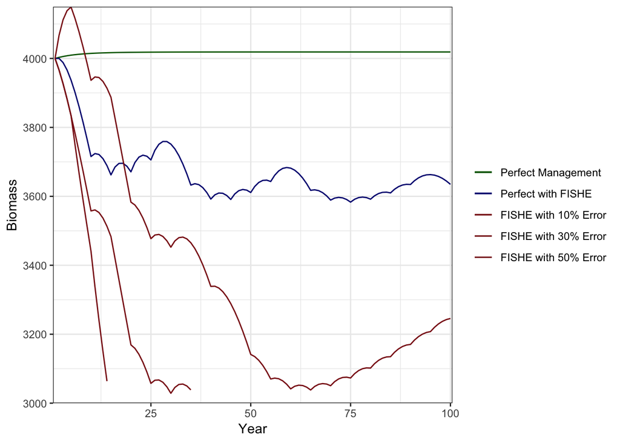

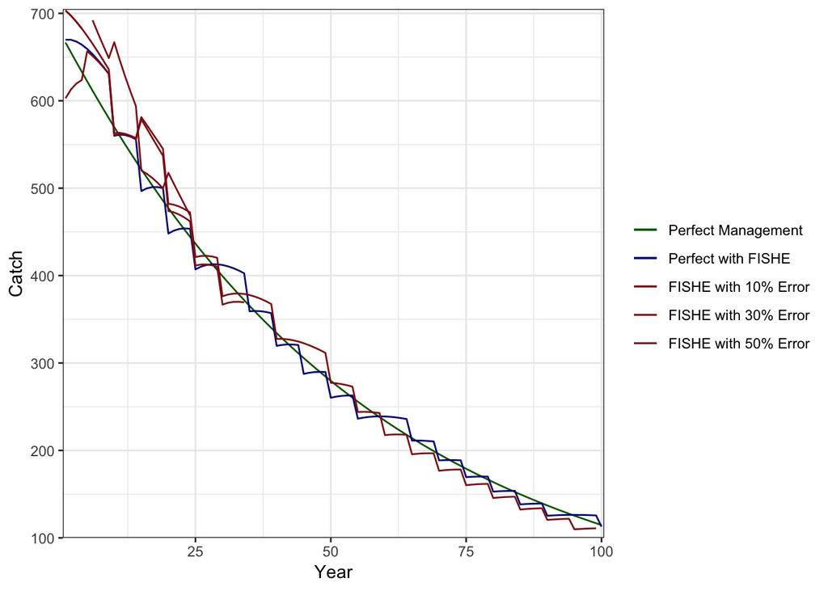

### Fast Growing

Initial Conditions of Experiment: - b0 = 4000 - r = 0.8 - r_s = -0.01767 - error = 0.1

Perfect Management: ID = 44 Perfect given FISHE: ID = 23 Error: ID = 23,

```r
#Find the right error experiment to use
err_fast <- err_rep5u %>%
  filter(r_s == -0.01767) %>%
  filter(r_0 == 0.8)
#Use experiment 23

#Find the experiment with same r0 and r_s for 0.3 error and 0.5 error
err_3f <- err_rep5u %>%
  filter(r_s == -0.01767) %>%
  filter(r_0 == 0.8) %>%
  filter(error == 0.3)
#431
err_5f <- err_rep5u %>%
  filter(r_s == -0.01767) %>%
  filter(r_0 == 0.8) %>%
  filter(error == 0.5)
#839
```

Graph biomass and catch over time for perfect management, perfect given FISHE, and the error simulation:

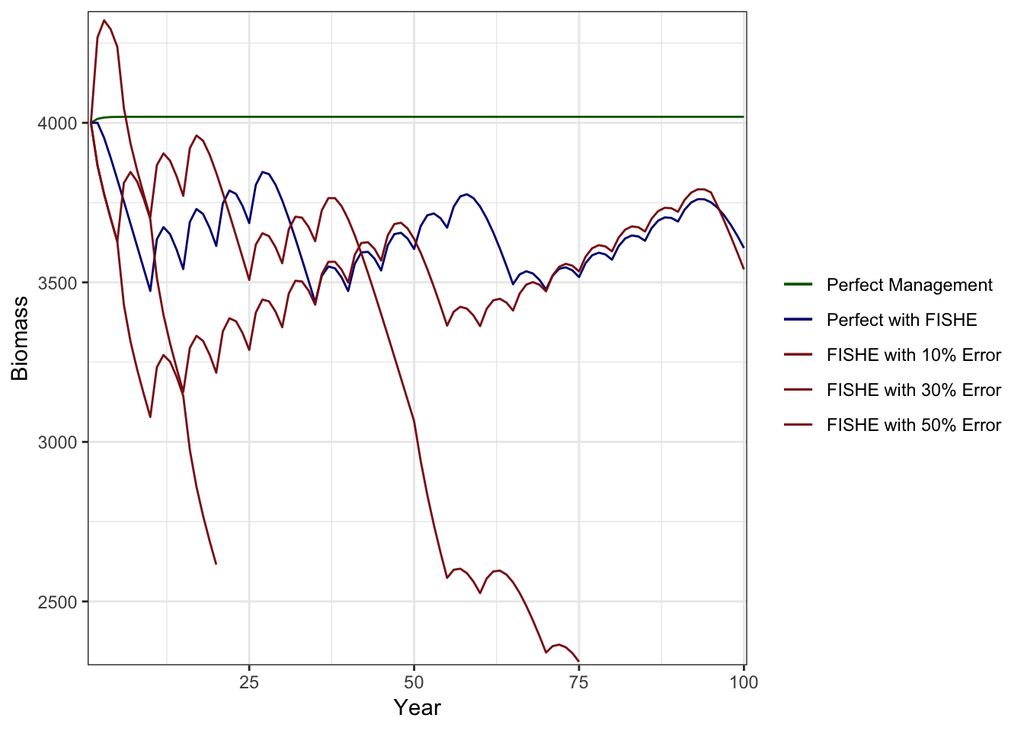

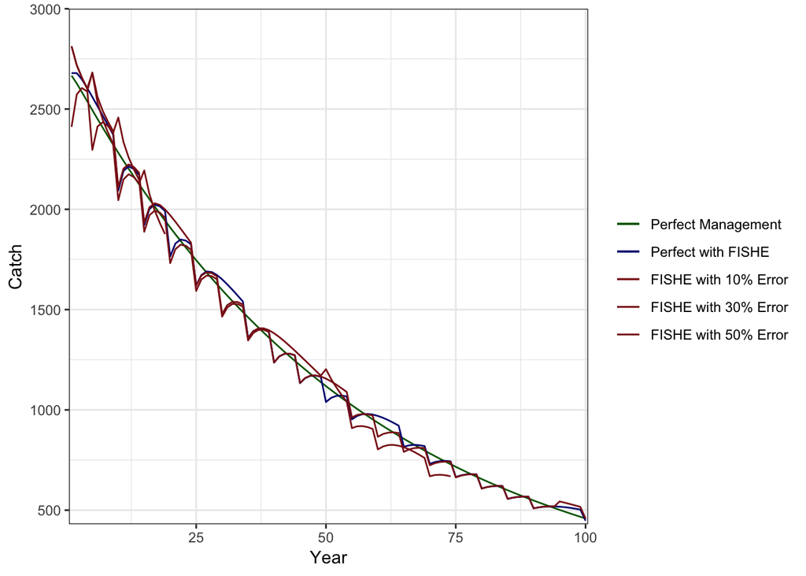